# Individual Model Fits (Pilot Data from 2 experiments)

Average error:

- Expt 1: 69.9 degrees (sd 9.6)
- Expt 2: 81.18 degrees (sd: 7.6)

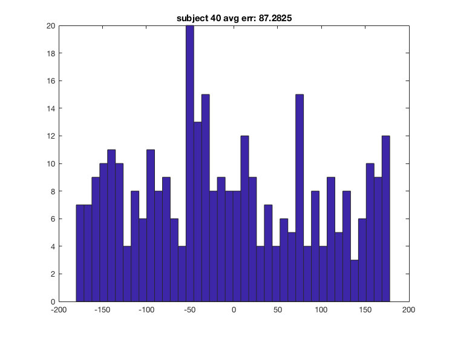

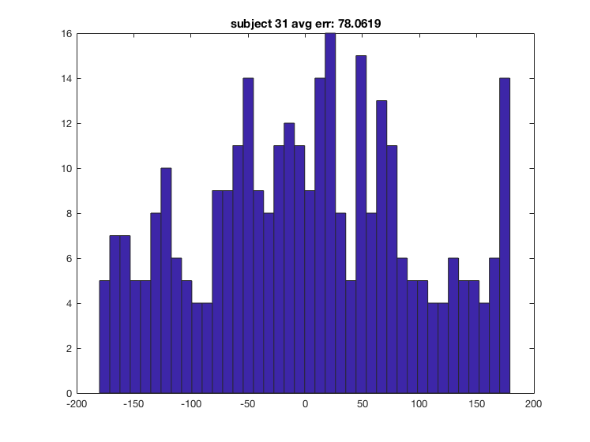

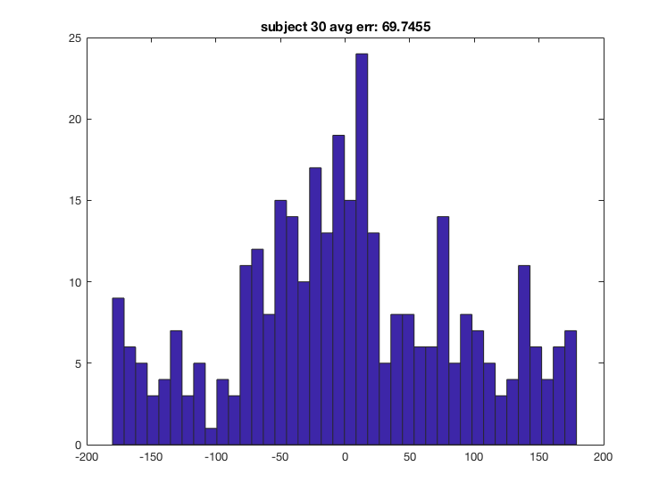

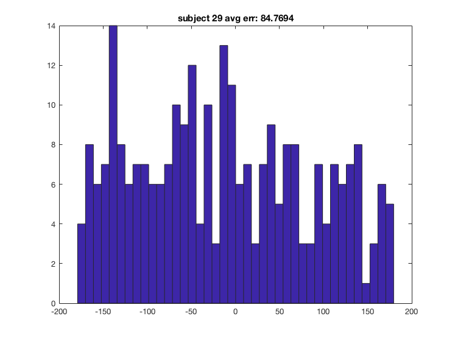

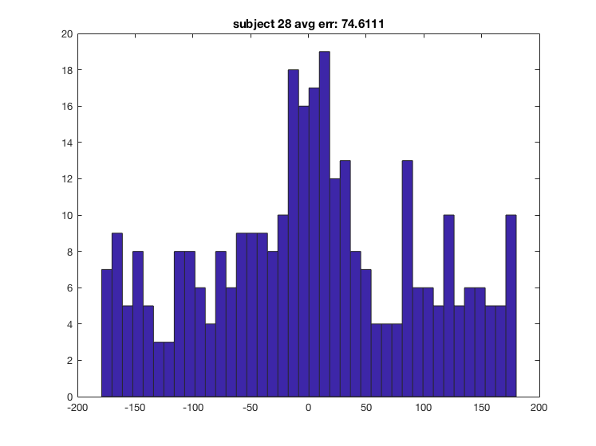

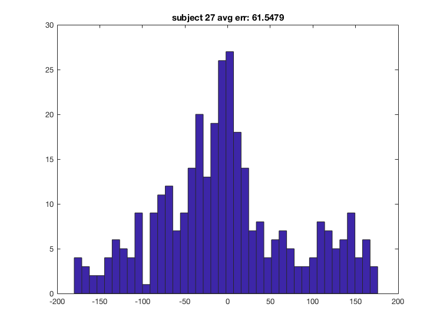

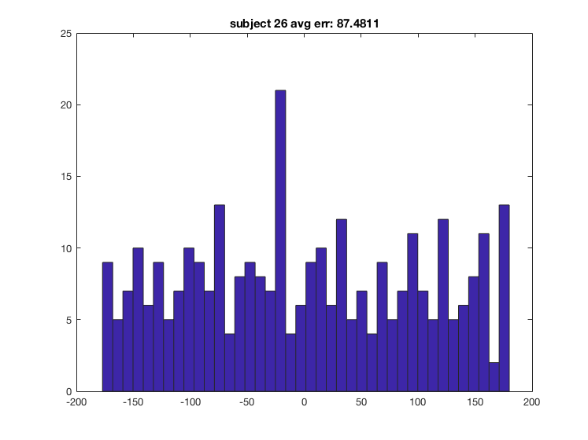

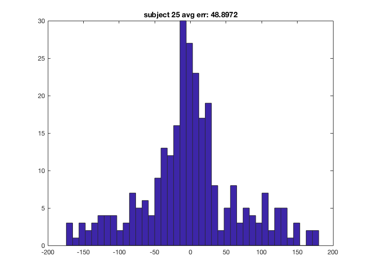

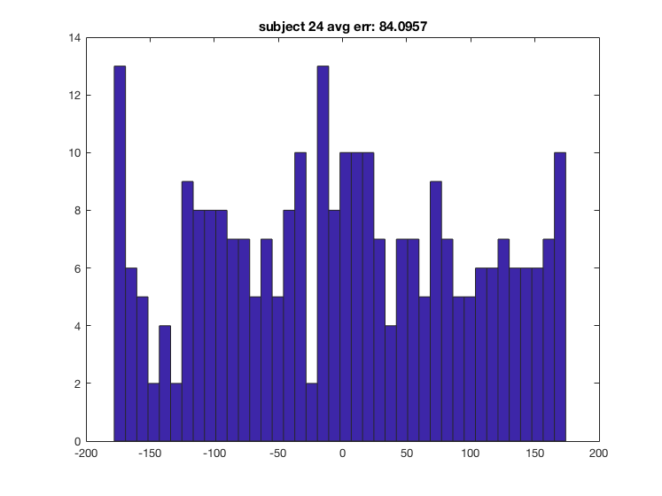

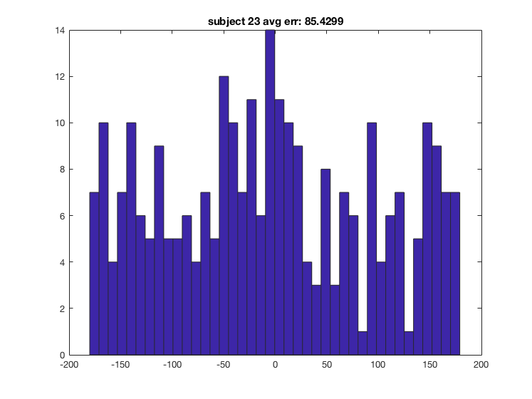

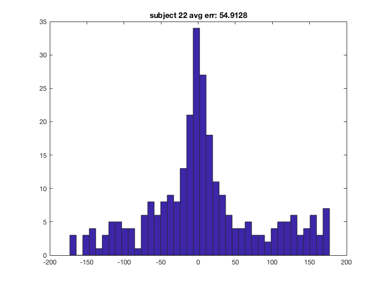

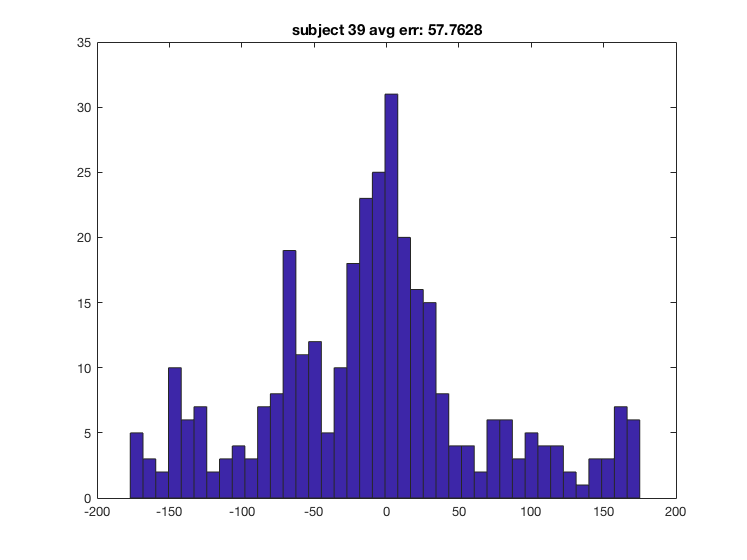

[28 more figures not shown]

```matlab
cd '/Users/scotti.5/Dropbox/Shared Lab Folder/Experiments/Contextual_LTM/Power analysis, collapsed v3 and v8'
openfig('histsubject1.fig');
openfig('histsubject2.fig');
openfig('histsubject3.fig');
openfig('histsubject4.fig');
openfig('histsubject5.fig');
openfig('histsubject6.fig');
openfig('histsubject7.fig');
openfig('histsubject8.fig');
openfig('histsubject9.fig');
openfig('histsubject10.fig');
openfig('histsubject11.fig');
openfig('histsubject12.fig');
openfig('histsubject13.fig');
openfig('histsubject14.fig');
openfig('histsubject15.fig');
openfig('histsubject16.fig');
openfig('histsubject17.fig');
openfig('histsubject18.fig');
openfig('histsubject19.fig');
openfig('histsubject20.fig');
openfig('histsubject21.fig');
openfig('histsubject22.fig');
openfig('histsubject23.fig');
openfig('histsubject24.fig');
openfig('histsubject25.fig');
openfig('histsubject26.fig');
openfig('histsubject27.fig');
openfig('histsubject28.fig');
openfig('histsubject29.fig');
openfig('histsubject30.fig');
openfig('histsubject31.fig');
openfig('histsubject32.fig');
openfig('histsubject33.fig');
openfig('histsubject34.fig');
openfig('histsubject35.fig');
openfig('histsubject36.fig');
openfig('histsubject37.fig');
openfig('histsubject38.fig');
openfig('histsubject39.fig');
openfig('histsubject40.fig');
```

Standard Mixture Model

Avg. Guessing:

- Expt 1: 43.2% (sd 29.18)
- Expt 2: 51.7% (sd 31.05)

Avg. SD:

- Expt 1: 185280 (sd 740930)
  - If excluding an outlier: avg 44.05 (sd 31.35)
- Expt 2: 2546 (sd 9655)
  - If excluding outliers (anyone waaaay above a normal SD): 53.15 (sd 44.07)

**I have the individual SMM fits if you'd like, but I didn't save their figures**

Modified Swap Model

Avg. Guessing across Expts:

- Expt 1: 25.2% (sd: 25.0)
- Expt 2: 54.1 (sd: 28.9)

Avg. Biased Proportion:

- Expt 1: 42.65% (25.89)
- Expt 2: 25.9% (29.1)

Avg. Target SD:

- Expt 1: 38.13 (26.9)
- Expt 2: 34.62 (25.2)

Avg. Biased SD:

- Expt 1: 93.86 (51.7)
- Expt 2: 79.10 (61.20)

Avg. Mean Shift **(given these errors are pos. if errors are towards rich quad and neg. if towards far quad)**

- Expt 1: 9.61 (25.5)
- Expt 2: -2.95 (25.7)

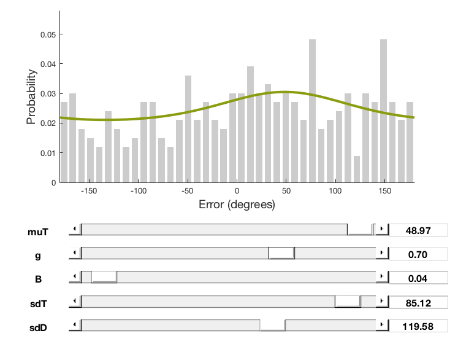

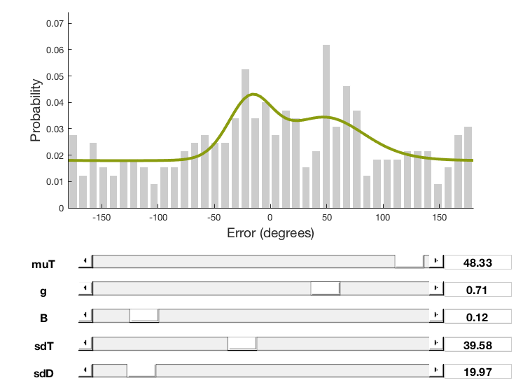

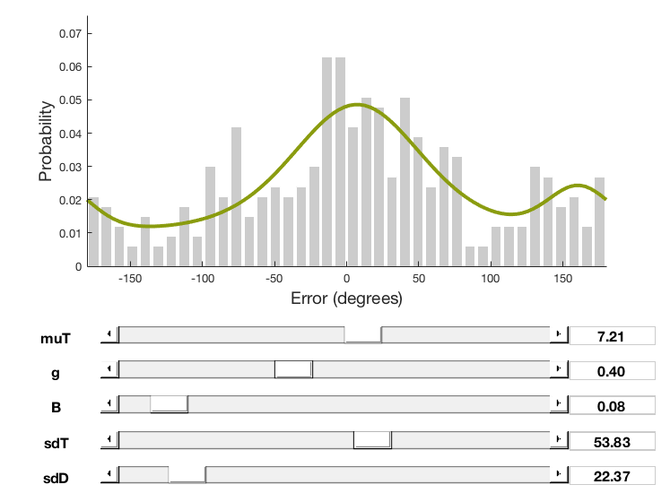

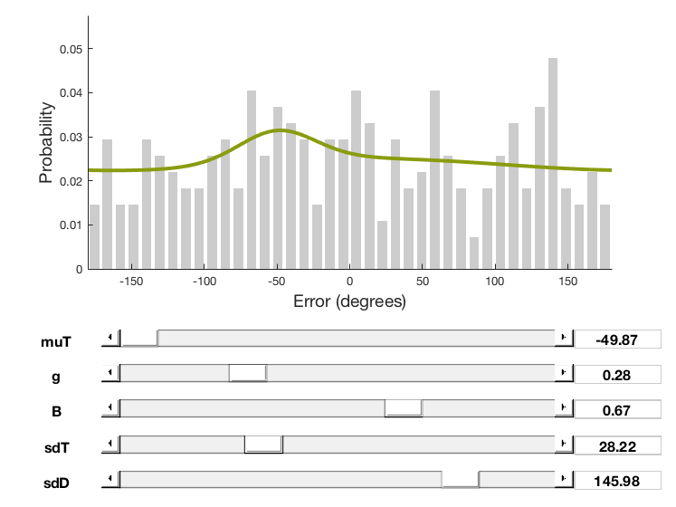

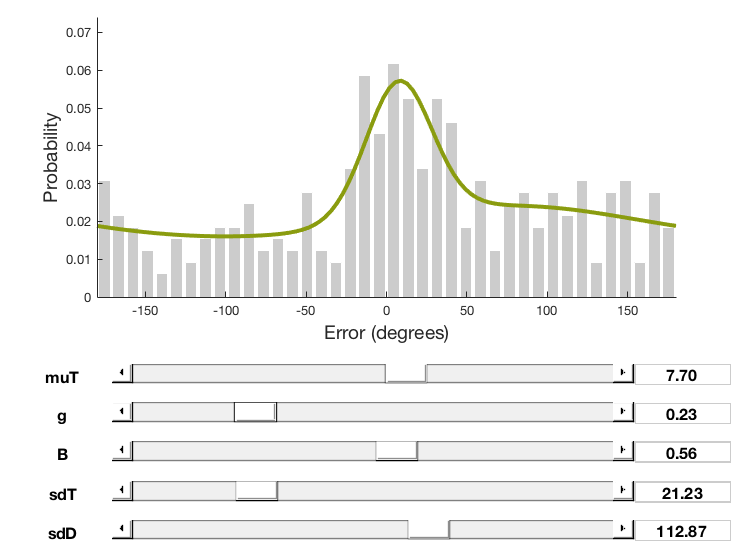

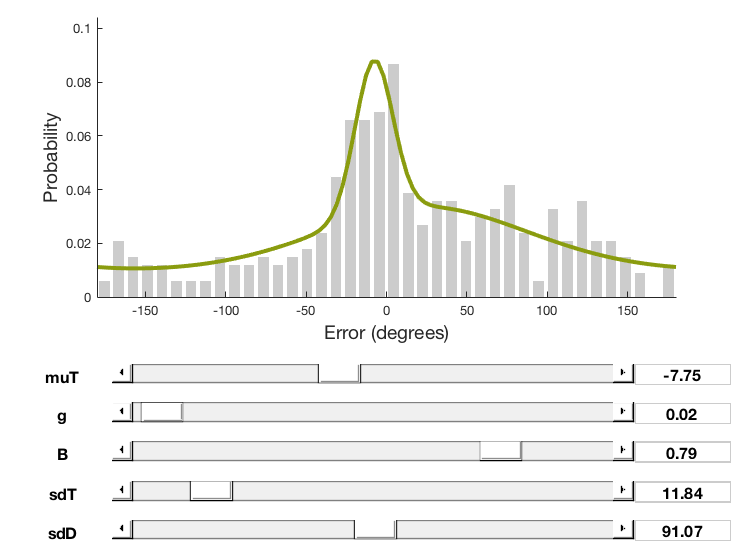

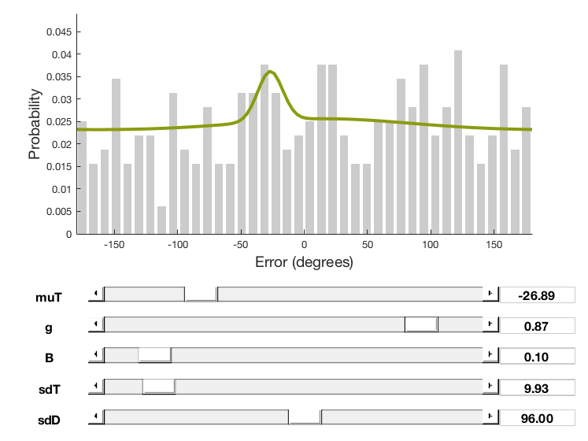

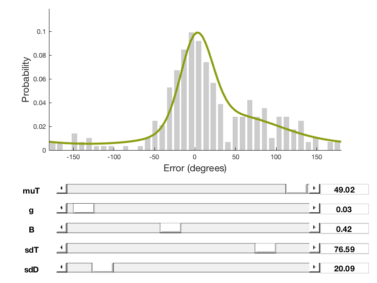

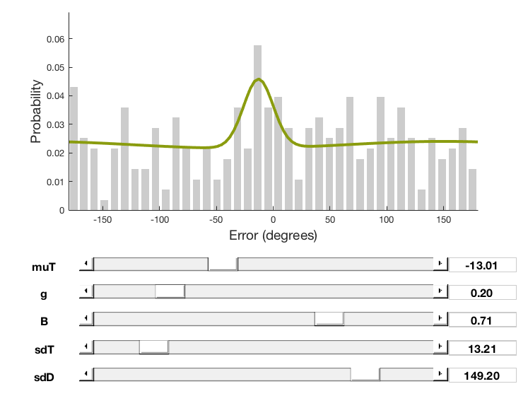

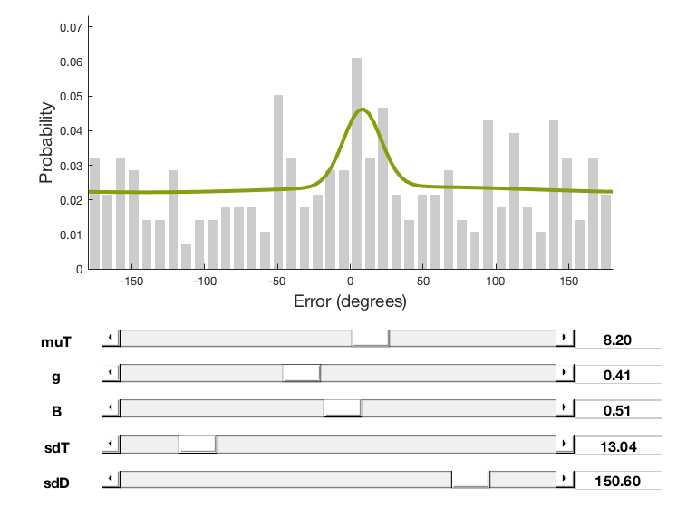

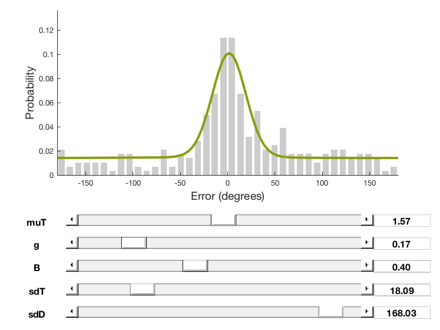

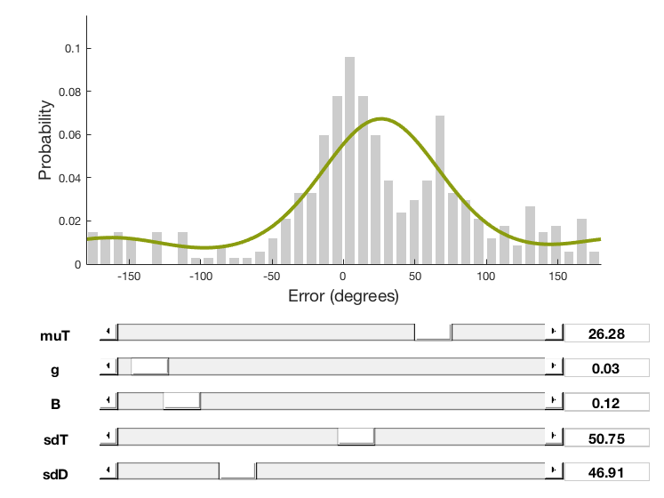

[28 more figures not shown]

```matlab
cd '/Users/scotti.5/Dropbox/Shared Lab Folder/Experiments/Contextual_LTM/Power analysis, collapsed v3 and v8'
openfig('Ho_subject1.fig');
openfig('Ho_subject2.fig');
openfig('Ho_subject3.fig');
openfig('Ho_subject4.fig');
openfig('Ho_subject5.fig');
openfig('Ho_subject6.fig');
openfig('Ho_subject7.fig');
openfig('Ho_subject8.fig');
openfig('Ho_subject9.fig');
openfig('Ho_subject10.fig');
openfig('Ho_subject11.fig');
openfig('Ho_subject12.fig');
openfig('Ho_subject13.fig');
openfig('Ho_subject14.fig');
openfig('Ho_subject15.fig');
openfig('Ho_subject16.fig');
openfig('Ho_subject17.fig');
openfig('Ho_subject18.fig');
openfig('Ho_subject19.fig');
openfig('Ho_subject20.fig');
openfig('Ho_subject21.fig');
openfig('Ho_subject22.fig');
openfig('Ho_subject23.fig');
openfig('Ho_subject24.fig');
openfig('Ho_subject25.fig');
openfig('Ho_subject26.fig');
openfig('Ho_subject27.fig');
openfig('Ho_subject28.fig');
openfig('Ho_subject29.fig');
openfig('Ho_subject30.fig');
openfig('Ho_subject31.fig');
openfig('Ho_subject32.fig');
openfig('Ho_subject33.fig');
openfig('Ho_subject34.fig');
openfig('Ho_subject35.fig');
openfig('Ho_subject36.fig');
openfig('Ho_subject37.fig');
openfig('Ho_subject38.fig');
openfig('Ho_subject39.fig');
openfig('Ho_subject40.fig');
```